# Session 10: Data Science Capstone Project

Rufei Wang

2022-12-19

# 1 Introduction and learning objectives

The purpose of this exercise is to build an estimation engine to guide investment decisions in London house market. You will first build machine learning algorithms (and tune them) to estimate the house prices given variety of information about each property. Then, using your algorithm, you will choose 200 houses to invest in out of about 2000 houses on the market at the moment.

**Learning objectives**

1. Using different data mining algorithms for prediction.
2. Dealing with large data sets
3. Tuning data mining algorithms
4. Interpreting data mining algorithms and deducing importance of variables
5. Using results of data mining algorithms to make business decisions

# 2 Load data

There are two sets of data, i) training data that has the actual prices ii) out of sample data that has the asking prices. Load both data sets.

Make sure you understand what information each column contains. Note that not all information provided might be useful in predicting house prices, but do not make any assumptions before you decide what information you use in your prediction algorithms.

```r
#read in the data

london_house_prices_2019_training<-read.csv("training_data_assignment_with_prices.csv")
london_house_prices_2019_out_of_sample<-read.csv("test_data_assignment.csv")


#fix data types in both data sets

#fix dates
london_house_prices_2019_training <- london_house_prices_2019_training %>% mutate(date=as.Date(date))
london_house_prices_2019_out_of_sample<-london_house_prices_2019_out_of_sample %>% mutate(date=as.Date(date))

#change characters to factors
london_house_prices_2019_training <- london_house_prices_2019_training %>% mutate_if(is.character,as.factor)
london_house_prices_2019_out_of_sample<-london_house_prices_2019_out_of_sample %>% mutate_if(is.character,as.factor)

#take a quick look at what's in the data
str(london_house_prices_2019_training)
```

```
## 'data.frame':    13998 obs. of  37 variables:
##  $ ID                          : int  2 3 4 5 7 8 9 10 11 12 ...
##  $ date                        : Date, format: "2019-11-01" "2019-08-08" ...
##  $ postcode                    : Factor w/ 12635 levels "BR1 1AB","BR1 1LR",..: 10897 11027 11264 2031 11241 11066 421 9594 9444 873 ...
##  $ property_type               : Factor w/ 4 levels "D","F","S","T": 2 2 3 2 3 2 1 4 4 2 ...
##  $ whether_old_or_new          : Factor w/ 2 levels "N","Y": 1 1 1 1 1 1 1 1 1 1 ...
##  $ freehold_or_leasehold       : Factor w/ 2 levels "F","L": 2 2 1 2 1 2 1 1 1 2 ...
##  $ address1                    : Factor w/ 2825 levels "1","1 - 2","1 - 3",..: 2503 792 253 789 569 234 264 418 5 274 ...
##  $ address2                    : Factor w/ 434 levels "1","10","101",..: 372 NA NA NA NA NA NA NA NA NA ...
##  $ address3                    : Factor w/ 8543 levels "ABBERTON WALK",..: 6990 6821 3715 2492 4168 2879 3620 5251 6045 6892 ...
##  $ town                        : Factor w/ 133 levels "ABBEY WOOD","ACTON",..: NA NA NA 78 NA NA NA NA NA NA ...
##  $ local_aut                   : Factor w/ 69 levels "ASHFORD","BARKING",..: 36 46 24 36 24 46 65 36 36 17 ...
##  $ county                      : Factor w/ 33 levels "BARKING AND DAGENHAM",..: 22 27 18 25 18 27 5 27 32 8 ...
##  $ postcode_short              : Factor w/ 247 levels "BR1","BR2","BR3",..: 190 194 198 28 198 194 4 169 167 8 ...
##  $ current_energy_rating       : Factor w/ 6 levels "B","C","D","E",..: 4 3 3 4 3 2 4 3 4 2 ...
```

[output cut: 23 more lines]

```r
str(london_house_prices_2019_out_of_sample)
```

```
## 'data.frame':    1999 obs. of  37 variables:
##  $ ID                          : int  14434 12562 8866 10721 1057 1527 13961 12108 9363 1155 ...
##  $ date                        : Date, format: NA NA ...
##  $ postcode                    : logi  NA NA NA NA NA NA ...
##  $ property_type               : Factor w/ 4 levels "D","F","S","T": 1 2 2 3 4 3 2 3 2 4 ...
##  $ whether_old_or_new          : Factor w/ 2 levels "N","Y": 1 1 1 1 1 1 1 1 1 1 ...
##  $ freehold_or_leasehold       : Factor w/ 2 levels "F","L": 1 2 2 1 1 1 2 1 2 1 ...
##  $ address1                    : logi  NA NA NA NA NA NA ...
##  $ address2                    : logi  NA NA NA NA NA NA ...
##  $ address3                    : logi  NA NA NA NA NA NA ...
##  $ town                        : Factor w/ 54 levels "ACTON","ADDISCOMBE",..: NA NA NA NA NA NA NA NA NA NA ...
##  $ local_aut                   : logi  NA NA NA NA NA NA ...
##  $ county                      : logi  NA NA NA NA NA NA ...
##  $ postcode_short              : Factor w/ 221 levels "BR1","BR2","BR3",..: 82 50 37 52 214 150 159 115 175 126 ...
##  $ current_energy_rating       : Factor w/ 6 levels "B","C","D","E",..: 3 2 3 3 4 4 4 3 4 3 ...
```

[output cut: 23 more lines]

```r
#let's do the initial split
library(rsample)
train_test_split <- initial_split(london_house_prices_2019_training, prop = 0.75) #training set contains 75% of the data

# Create the training dataset
train_data <- training(train_test_split)
test_data <- testing(train_test_split)
```

# 3 Visualize data

Visualize and examine the data. What plots could be useful here? What do you learn from these visualizations? - To explore and examine data, I would draw scatter plots to investigate correlations, line graphs to investigate the change of pricing over time. - Firstly I explored how housing prices changed by different types of properties. We can see that there had been fluctuations among all types of properties but both the mean and median prices fluctuated the most for detached properties.

[figure not shown]

```r
# median price change
london_house_prices_2019_training %>%
  group_by(property_type, date) %>%
  mutate(median_price = median(price)) %>%

ggplot() +
  aes(x = date, y =  median_price, color = property_type) +
  geom_line() +
  facet_grid() +
  labs(title = "Median Housing Prices Fluctuations by Property Types", subtitle = "Detached property prices fluctuated the most",
       y = "Date",
       x = "Median Price",
       color= "Property Types") +
  theme_minimal()
```

[figure not shown]

```r
# average price change
london_house_prices_2019_training %>%
  group_by(property_type, date) %>%
  mutate(avg_price = mean(price)) %>%

ggplot() +
  aes(x = date, y =  avg_price, color = property_type) +
  geom_line() +
  facet_grid() +
  labs(title = "Average Housing Prices Fluctuations by Property Types", subtitle = "Detached property prices fluctuated the most",
       y = "Date",
       x = "Average Price",
       color= "Property Types") +
  theme_minimal()
```

[figure not shown]

```r
london_house_prices_2019_training %>%
  ggplot(aes(x = price)) +
  geom_histogram() +
  labs(title = "Prices are Negatively Skewed",
       y = "Count",
       x = "Price") +
  theme_minimal()
```

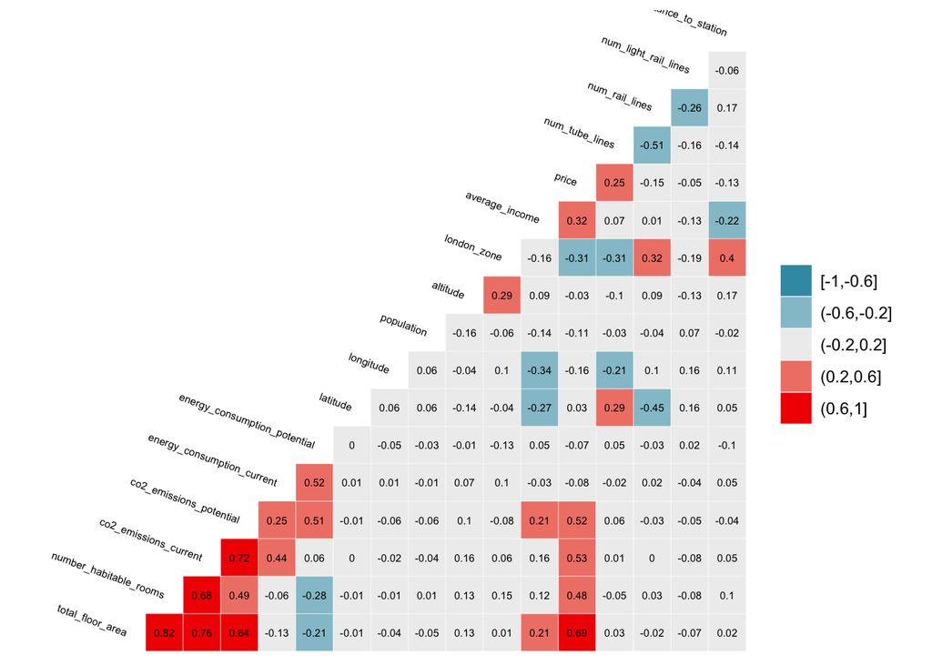

```r
# produce a correlation table using GGally::ggcor()
# this takes a while to plot

library("GGally")
london_house_prices_2019_training %>%
  select(-ID) %>% #keep Y variable last
  ggcorr(method = c("pairwise", "pearson"), layout.exp = 2,label_round=2, label = TRUE,label_size = 2,hjust = 1,nbreaks = 5,size = 2,angle = -20)
```

Now I’ll explore further the correlation between total_floor_area and price because that had the highest correlation from the correlation table we drew previously. I also included the scatterplot of number of habitable rooms in the same graph. There are strong correlations between total floor area and price as well as number of habitable rooms and price.

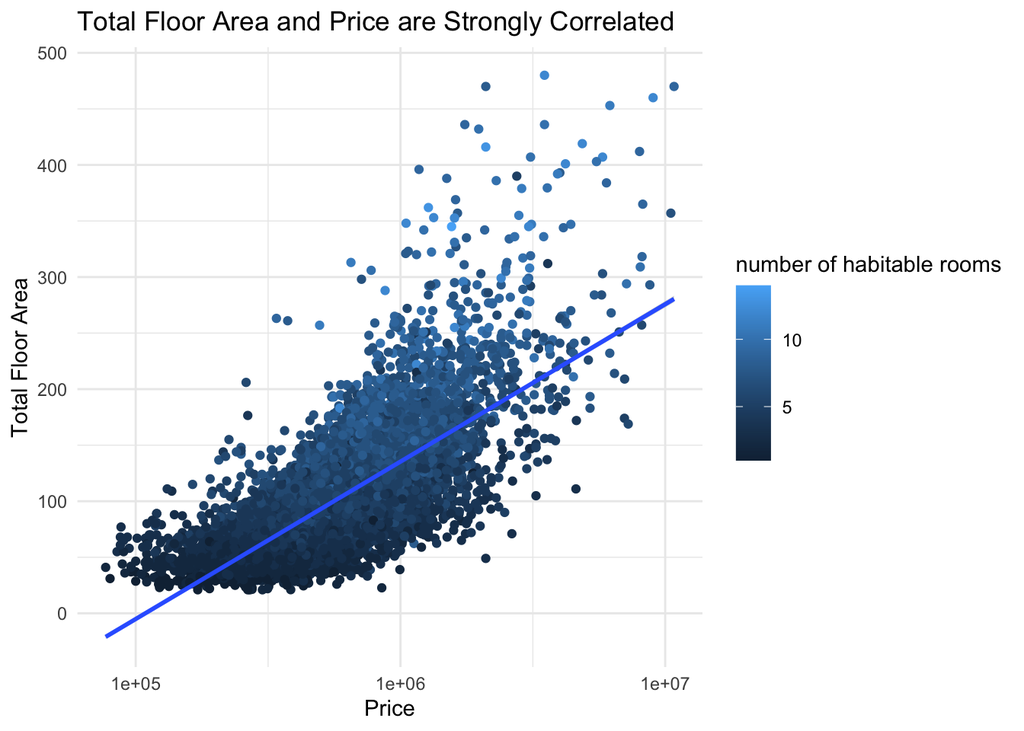

```r
london_house_prices_2019_training %>%
  ggplot(aes(x = price,
             y = total_floor_area)) +
  geom_point(aes(color = number_habitable_rooms)) +
  scale_x_log10() +
  geom_smooth(method = "lm") +
  labs(title = "Total Floor Area and Price are Strongly Correlated",
       y = "Total Floor Area",
       x = "Price",
       color= "number of habitable rooms") +
  theme_minimal()
```

Finally I want to explore the correlation between london zones and price as well as distance to station and price respectively. I learnt that there is weak negative correlation for both pairs.

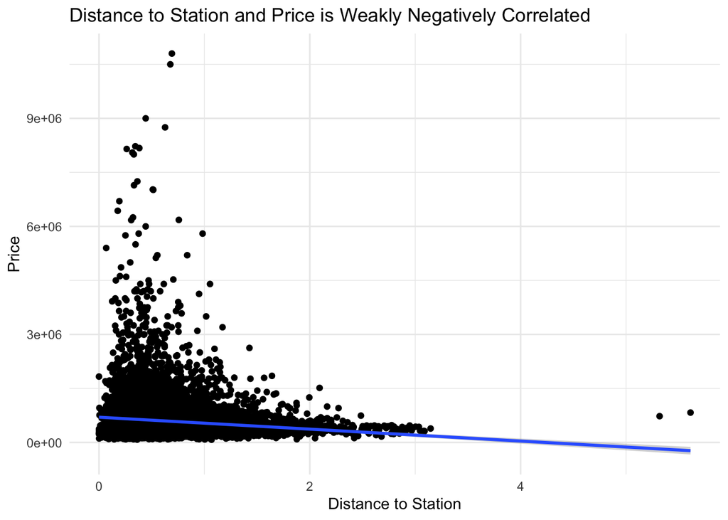

```r
# There is weak correlation between distance to station and price
london_house_prices_2019_training %>%
  ggplot(aes(x = distance_to_station, y = price)) +
  geom_point() +
  geom_smooth(method = "lm") +
  labs(title = "Distance to Station and Price is Weakly Negatively Correlated",
       x = "Distance to Station",
       y = "Price") +
  theme_minimal()
```

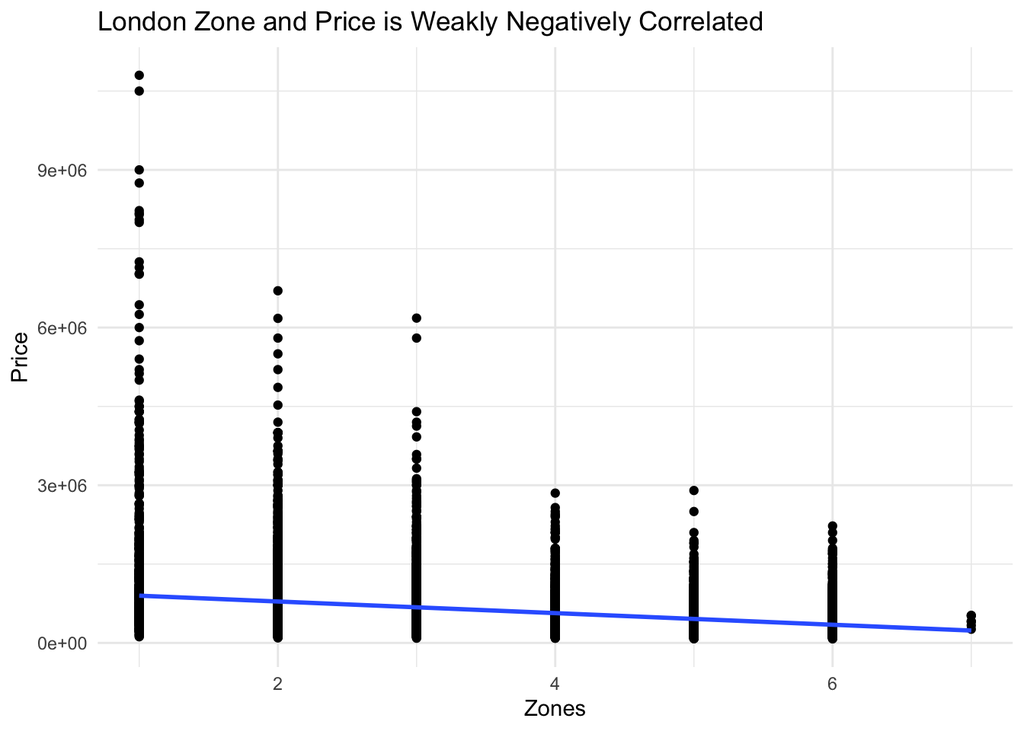

```r
# There is also weak correlation between London Zone and price
london_house_prices_2019_training %>%
  ggplot(aes(x = london_zone, y = price)) +
  geom_point() +
  geom_smooth(method = "lm") +
  labs(title = "London Zone and Price is Weakly Negatively Correlated",
       x = "Zones",
       y = "Price") +
  theme_minimal()
```

# 4 Fit a linear regression model

To help you get started I build a linear regression model below. I chose a subset of the features with no particular goal. You can (and should) add more variables and/or choose variable selection methods if you want.

```r
#Define control variables
control <- trainControl (
    method="cv",
    number=5,
    verboseIter=TRUE) #by setting this to true the model will report its progress after each estimation

#we are going to train the model and report the results using k-fold cross validation
model1_lm<-train(
    price ~ distance_to_station +water_company+property_type+whether_old_or_new+freehold_or_leasehold+latitude+ longitude,
    train_data,
   method = "lm",
    trControl = control
   )
# summary of the results
summary(model1_lm)
```

```
##
## Call:
## lm(formula = .outcome ~ ., data = dat)
##
## Residuals:
##      Min       1Q   Median       3Q      Max
##  -904773  -195896   -67770    69730 10001210
##
## Coefficients:
##                                       Estimate Std. Error t value Pr(>|t|)
## (Intercept)                          -46704657    3664557 -12.745  < 2e-16 ***
## distance_to_station                    -150314      12298 -12.222  < 2e-16 ***
## `water_companyEssex & Suffolk Water`    407225      29320  13.889  < 2e-16 ***
## `water_companyLeep Utilities`           534806     271272   1.971   0.0487 *
## `water_companySES Water`                280224      29723   9.428  < 2e-16 ***
## `water_companyThames Water`             496382      19862  24.991  < 2e-16 ***
## property_typeF                         -460895      41228 -11.179  < 2e-16 ***
## property_typeS                         -317621      21654 -14.668  < 2e-16 ***
## property_typeT                         -360133      20757 -17.350  < 2e-16 ***
## whether_old_or_newY                      -9513     177135  -0.054   0.9572
## freehold_or_leaseholdL                 -164823      36225  -4.550 5.42e-06 ***
## latitude                                918559      71034  12.931  < 2e-16 ***
## longitude                             -1030019      40549 -25.402  < 2e-16 ***
## ---
## Signif. codes:  0 '***' 0.001 '**' 0.01 '*' 0.05 '.' 0.1 ' ' 1
##
## Residual standard error: 468200 on 10485 degrees of freedom
## Multiple R-squared:  0.1795, Adjusted R-squared:  0.1786
## F-statistic: 191.1 on 12 and 10485 DF,  p-value: < 2.2e-16
```

```r
model2_lm <- train(
   price ~  I(average_income^2) +
            log(london_zone) +
            I(total_floor_area^2) +
            log(co2_emissions_current) +
            average_income:number_habitable_rooms:total_floor_area +
            distance_to_station +
            district +
            longitude +
            property_type +
            whether_old_or_new +
            water_company +
            tenure +
            freehold_or_leasehold,
    metric = "RMSE",
    na.action = na.omit,
    train_data,
   method = "lm",
    trControl = control
   )
# summary of the results
summary(model2_lm)
```

```
##
## Call:
## lm(formula = .outcome ~ ., data = dat)
##
## Residuals:
##      Min       1Q   Median       3Q      Max
## -2897139   -83944     3045    82291  6140251
##
## Coefficients:
##                                                            Estimate Std. Error
## (Intercept)                                               2.525e+05  5.164e+04
## `I(average_income^2)`                                     6.756e-05  3.996e-06
## `log(london_zone)`                                       -2.424e+05  1.375e+04
## `I(total_floor_area^2)`                                   2.090e+01  6.526e-01
## `log(co2_emissions_current)`                              8.737e+04  8.014e+03
## distance_to_station                                      -8.821e+03  7.969e+03
## districtBarnet                                            1.451e+05  4.588e+04
## districtBexley                                           -7.985e+04  3.852e+04
## districtBrent                                             2.034e+05  5.030e+04
## districtBromley                                          -3.211e+04  3.763e+04
## districtCamden                                            2.810e+05  4.670e+04
## `districtCity of London`                                 -1.435e+05  1.716e+05
## districtCroydon                                          -3.648e+04  4.054e+04
## districtEaling                                            1.590e+05  5.311e+04
## districtEnfield                                           5.289e+04  4.071e+04
## districtGreenwich                                        -4.935e+04  3.852e+04
## districtHackney                                           1.034e+05  4.324e+04
## `districtHammersmith and Fulham`                          3.378e+05  5.090e+04
## districtHaringey                                          1.088e+05  4.442e+04
## districtHarrow                                            1.917e+05  5.705e+04
## districtHavering                                          1.980e+04  2.501e+04
## districtHillingdon                                        2.438e+05  5.933e+04
## districtHounslow                                          2.072e+05  5.449e+04
## districtIslington                                         1.533e+05  4.638e+04
## `districtKensington and Chelsea`                          9.002e+05  5.021e+04
## `districtKingston upon Thames`                            1.477e+05  5.012e+04
## districtLambeth                                           5.518e+04  4.425e+04
## districtLewisham                                         -5.696e+04  3.936e+04
## districtMerton                                            6.832e+04  4.647e+04
## districtNewham                                           -7.814e+04  4.204e+04
```

[output cut: 64 more lines]

```
## whether_old_or_newY                                        0.775 0.438487
## `water_companyEssex & Suffolk Water`                      -0.578 0.563580
## `water_companyLeep Utilities`                              0.336 0.737238
## `water_companySES Water`                                   0.093 0.925796
## `water_companyThames Water`                                2.143 0.032157 *
## `tenurerental (private)`                                  -1.881 0.060022 .
## `tenurerental (social)`                                   -2.165 0.030376 *
## freehold_or_leaseholdL                                    -2.121 0.033959 *
## `average_income:number_habitable_rooms:total_floor_area`   0.599 0.548937
## ---
## Signif. codes:  0 '***' 0.001 '**' 0.01 '*' 0.05 '.' 0.1 ' ' 1
##
## Residual standard error: 287200 on 10447 degrees of freedom
## Multiple R-squared:  0.6923, Adjusted R-squared:  0.6908
## F-statistic: 470.1 on 50 and 10447 DF,  p-value: < 2.2e-16
```

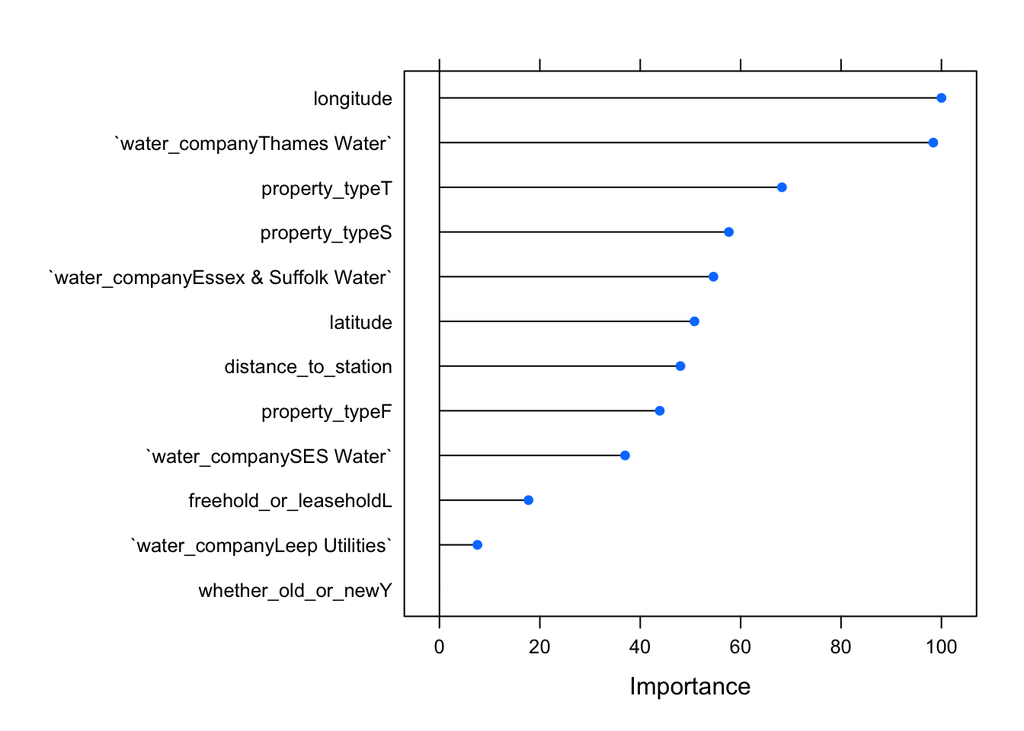

```r
# we can check variable importance as well
importance1 <- varImp(model1_lm, scale=TRUE)
plot(importance1)
```

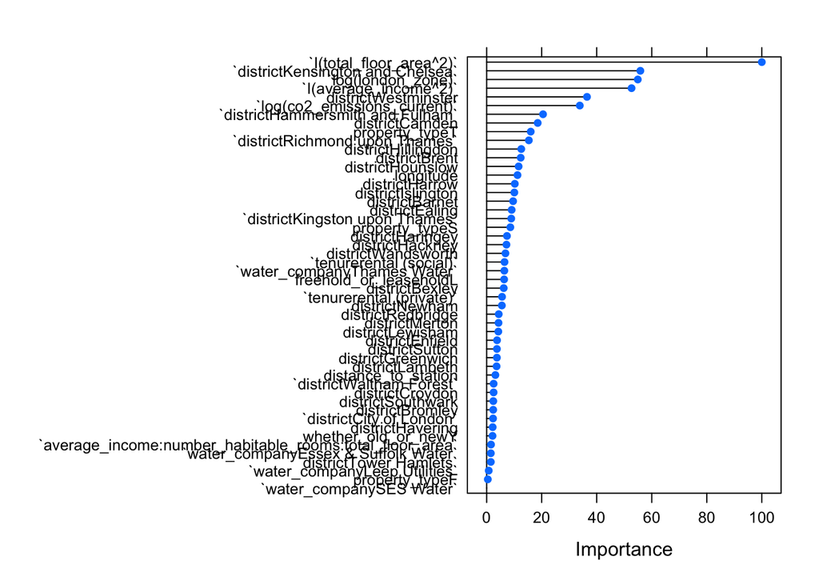

```r
# for model
importance2 <- varImp(model2_lm, scale=TRUE)
plot(importance2)
```

## 4.1 Predict the values in testing and out of sample data

Below I use the predict function to test the performance of the model in testing data and summarize the performance of the linear regression model. How can you measure the quality of your predictions?

```r
# We can predict the testing values
predictions <- predict(model2_lm,test_data)

lr_results <- data.frame(  RMSE = RMSE(predictions, test_data$price),
                            Rsquare = R2(predictions, test_data$price))


lr_results
```

```
##       RMSE   Rsquare
## 1 264317.4 0.7501814
```

```r
# We can predict prices for out of sample data the same way
predictions_oos <- predict(model2_lm,london_house_prices_2019_out_of_sample)
```

# 5 Fit a tree model

```r
# improved tree model
set.seed(1234)
model3_tree <- train(
  price ~ average_income +
          water_company +
          property_type +
          whether_old_or_new +
          total_floor_area +
          longitude +
          london_zone +
          average_income +
          distance_to_station +
          co2_emissions_current,
  train_data,
  method = "rpart",
  trControl = control,
  tuneLength = 20)
```

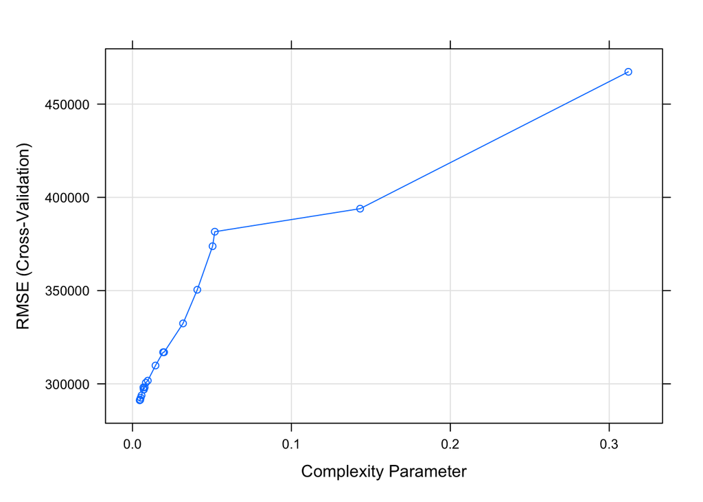

```r
#View how the tree performs and the best tune
plot(model3_tree)
```

```r
# the tree performance
model3_tree$results[which.min(model3_tree$results$RMSE),]
```

```
##            cp     RMSE  Rsquared      MAE   RMSESD RsquaredSD    MAESD
## 1 0.004523137 291202.3 0.6854493 153895.1 32632.19 0.03060649 5730.007
```

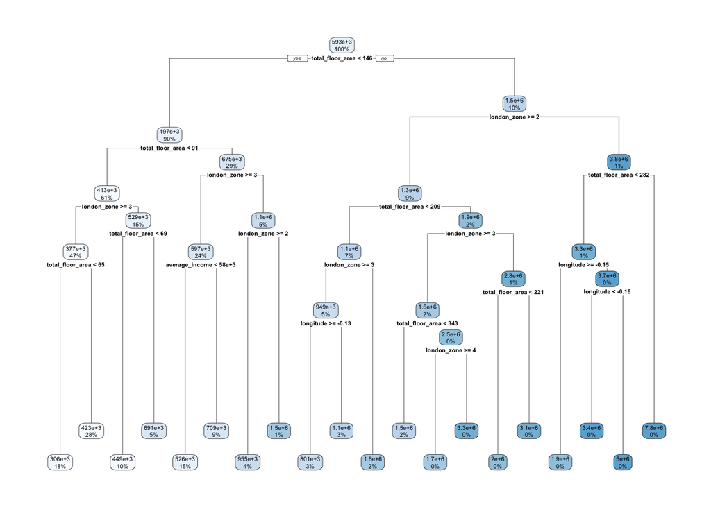

```r
# the final tree output
rpart.plot(model3_tree$finalModel)
```

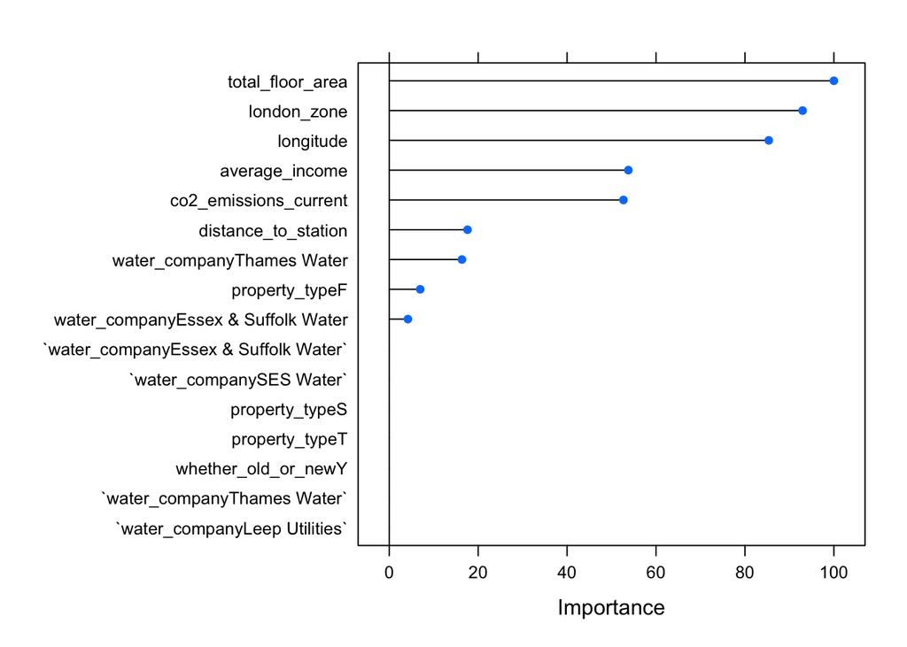

```r
# the variable importance
importance <- varImp(model3_tree, scale=TRUE)
plot(importance)
```

# 6 Other algorithms

Use at least two other algorithms to predict prices. Don’t forget to tune the parameters of these algorithms. And then compare the performances of your algorithms to linear regression and trees.

```r
set.seed(1234)
# finding optimal lambda
lambda_seq <- seq(10000,12000, length = 1000)

# using k-fold cross validation to select the best lambda
lasso <- train(
 price ~ water_company +
   property_type +
   whether_old_or_new +
   total_floor_area +
   latitude +
   longitude +
   london_zone +
   average_income +
   num_tube_lines +
   type_of_closest_station +
   distance_to_station +
   current_energy_rating +
   co2_emissions_current +
   windows_energy_eff +
   co2_emissions_potential,
 data = na.omit(train_data),
 method = "glmnet",
 trControl = control,
 tuneGrid = expand.grid(alpha = 1, lambda = lambda_seq))
# training the model using k-fold cross validation
model4_lasso <- train(
    price ~ average_income +
          water_company +
          property_type +
          whether_old_or_new +
          total_floor_area +
          longitude +
          london_zone +
          average_income +
          distance_to_station +
          co2_emissions_current,
    train_data,
   method = "lm",
    trControl = control
   )
# summary of the results
summary(model4_lasso)
```

```
##
## Call:
## lm(formula = .outcome ~ ., data = dat)
##
## Residuals:
##      Min       1Q   Median       3Q      Max
## -1767549  -125669   -12603    95170  7472127
##
## Coefficients:
##                                        Estimate Std. Error t value Pr(>|t|)
## (Intercept)                          -3.391e+05  3.628e+04  -9.344  < 2e-16 ***
## average_income                        6.873e+00  4.344e-01  15.823  < 2e-16 ***
## `water_companyEssex & Suffolk Water`  2.093e+05  2.045e+04  10.235  < 2e-16 ***
## `water_companyLeep Utilities`        -1.034e+04  1.894e+05  -0.055   0.9565
## `water_companySES Water`             -1.955e+04  1.758e+04  -1.112   0.2661
## `water_companyThames Water`           6.319e+04  1.360e+04   4.647 3.41e-06 ***
## property_typeF                        9.184e+04  1.768e+04   5.195 2.08e-07 ***
## property_typeS                        3.611e+04  1.563e+04   2.310   0.0209 *
## property_typeT                        7.860e+04  1.571e+04   5.003 5.75e-07 ***
## whether_old_or_newY                   3.402e+04  1.237e+05   0.275   0.7833
## total_floor_area                      7.333e+03  1.156e+02  63.435  < 2e-16 ***
## longitude                            -4.353e+05  2.953e+04 -14.741  < 2e-16 ***
## london_zone                          -9.842e+04  2.945e+03 -33.417  < 2e-16 ***
## distance_to_station                   2.594e+03  8.880e+03   0.292   0.7702
## co2_emissions_current                 1.525e+04  2.100e+03   7.264 4.03e-13 ***
## ---
## Signif. codes:  0 '***' 0.001 '**' 0.01 '*' 0.05 '.' 0.1 ' ' 1
##
## Residual standard error: 326800 on 10483 degrees of freedom
## Multiple R-squared:  0.6003, Adjusted R-squared:  0.5998
## F-statistic:  1125 on 14 and 10483 DF,  p-value: < 2.2e-16
```

```r
set.seed(1234)
model5_rft <- train(
  price ~ average_income +
          water_company +
          property_type +
          whether_old_or_new +
          total_floor_area +
          longitude +
          london_zone +
          average_income +
          distance_to_station +
          co2_emissions_current,
  train_data,
  method = "ranger",
  trControl = trainControl(method = "cv",
                           number = 5,
                           verboseIter = TRUE),
  tuneGrid = expand.grid(.mtry = c(5:10),
                         .splitrule = "variance",
                         .min.node.size = c(1:4)),
  importance = "impurity"
)
# choose the optimal result
model5_rft$results %>%
  slice_max(order_by = RMSE, n=5)
```

```
##   mtry splitrule min.node.size     RMSE  Rsquared      MAE   RMSESD RsquaredSD
## 1   10  variance             1 229296.1 0.8051839 107222.4 34933.54 0.02946381
## 2   10  variance             4 229291.5 0.8052091 107246.9 33151.85 0.02674116
## 3   10  variance             3 228804.6 0.8056708 107211.6 35028.64 0.02934852
## 4    5  variance             4 228591.6 0.8093229 106021.9 36633.32 0.02610708
## 5    5  variance             2 228433.8 0.8094270 105992.9 36598.29 0.02599596
##      MAESD
## 1 6403.517
## 2 6074.665
## 3 6389.270
## 4 5803.489
## 5 6093.869
```

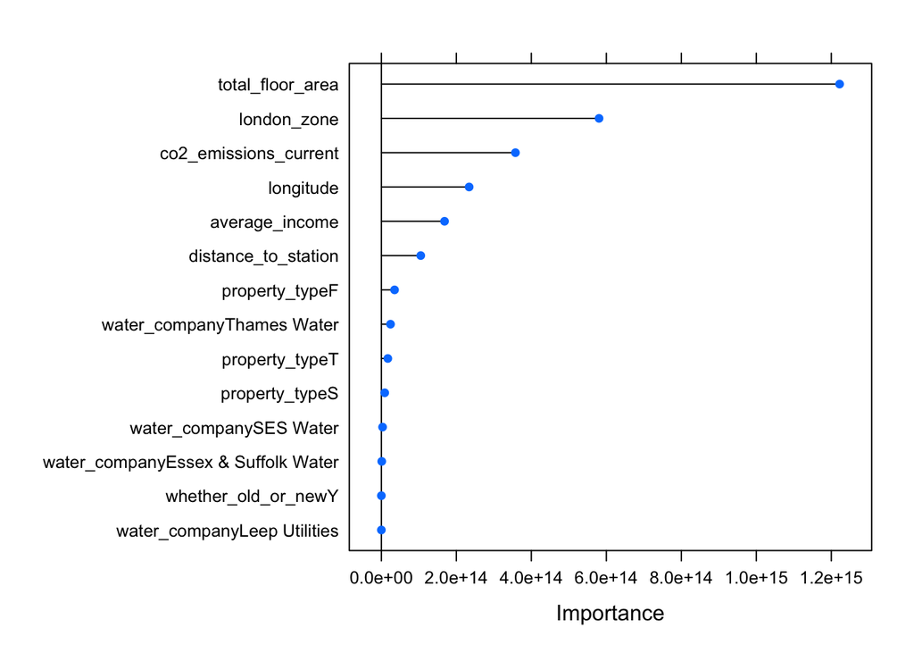

```r
# variable importance
plot(varImp(model5_rft, scale = FALSE))
```

# 7 Stacking

```r
model_list <- caretList(
  price ~ average_income +
          water_company +
          property_type +
          whether_old_or_new +
          total_floor_area +
          longitude +
          london_zone +
          average_income +
          distance_to_station +
          co2_emissions_current,
  train_data,
  trControl = control,
  tuneList = list(
    model5_rft = caretModelSpec(method = "ranger", tuneGrid = expand.grid(.mtry = 5,
                                                                       .splitrule = "variance",
                                                                       .min.node.size = 3)),
    model2_lm = caretModelSpec(method = "lm"),
    model4_lasso = caretModelSpec(method = "lasso", tuneGrid = data.frame(fraction =0.8578947)))
    )
lm_ensemble <- caretStack(
    model_list,
    method="lm",
    trControl=control
  )
summary(lm_ensemble)
```

```
##
## Call:
## lm(formula = .outcome ~ ., data = dat)
##
## Residuals:
##      Min       1Q   Median       3Q      Max
## -2779450   -59893    -3847    54648  4020659
##
## Coefficients:
##                Estimate Std. Error t value Pr(>|t|)
## (Intercept)  -3.498e+04  4.024e+03  -8.694  < 2e-16 ***
## model5_rft    1.161e+00  1.003e-02 115.668  < 2e-16 ***
## model2_lm    -6.284e-01  1.344e-01  -4.674    3e-06 ***
## model4_lasso  5.248e-01  1.359e-01   3.862 0.000113 ***
## ---
## Signif. codes:  0 '***' 0.001 '**' 0.01 '*' 0.05 '.' 0.1 ' ' 1
##
## Residual standard error: 217500 on 10494 degrees of freedom
## Multiple R-squared:  0.8227, Adjusted R-squared:  0.8227
## F-statistic: 1.623e+04 on 3 and 10494 DF,  p-value: < 2.2e-16
```

# 8 Pick investments

In this section you should use the best algorithm you identified to choose 200 properties from the out of sample data.

```r
numchoose=200

oos <- london_house_prices_2019_out_of_sample

#predict the value of houses
oos$predict <- predict(lm_ensemble,oos)

#choose investment by selecting the highest percentage returns properties
buy_selection <- oos %>%
  mutate(price_change = (predict - asking_price)/asking_price) %>%
  slice_max(order_by = price_change, n = numchoose)

# Select only the properties of interest
oos <- oos %>%
  mutate(buy = case_when(ID %in% buy_selection$ID ~ 1,
                         TRUE ~0))

#output choices
write.csv(oos,"Rufei_Wang.csv")
```